# DataPreplesson2

```python
import pandas as pd
pd.set_option('display.max_rows', 1000)
pd.set_option('display.max_columns', 500)
#pd.set_option('display.max_width', 1000)
pd.set_option('display.max_colwidth', 1000)
import numpy as np
import matplotlib.pyplot as plt
#pip install seaborn
import seaborn as sns
import missingno as msno
#pip install datatble
#import datatable as dt
```

Riikka Formulahti 2003088 NAI20SP

```python
data = pd.read_csv('task_2_dapre.csv')

data.sample(10)
```

|  | DATA_YEAR_x | ARRESTEE_ID | INCIDENT_ID | ARREST_DATE | AGE_NUM | SEX_CODE | RACE_ID | RESIDENT_CODE | ARREST_TYPE_NAME | INCIDENT_HOUR | OFFENSE_NAME | CRIME_AGAINST | HC_CODE | OFFENSE_CATEGORY_NAME | RACE_DESC |
| --- | --- | --- | --- | --- | --- | --- | --- | --- | --- | --- | --- | --- | --- | --- | --- |
| 837 | 2020 | 41260367 | 133589030 | 16.Jul.20 | 56 | M | 1 | R | Taken INTO Custody | 19 | Simple Assault | Person | 9,,0 | Assault Offenses | White |
| 58 | 2020 | 41263573 | 133604603 | 15.Sep.20 | 31 | M | 1 | NaN | On View | 9 | Burglary/Breaking & Entering | Property | 5,,0 | Burglary/Breaking & Entering | White |
| 376 | 2020 | 41282272 | 133664448 | 7.Dec.20 | 17 | M | 2 | R | Taken INTO Custody | 22 | Theft From Motor Vehicle | Property | NaN | Larceny/Theft Offenses | Black or African American |
| 1552 | 2020 | 41274174 | 133635567 | 7.Nov.20 | 25 | F | 1 | R | On View | 17 | Arson | Property | 8,,0 | Arson | White |
| 898 | 2020 | 41273933 | 133634791 | 28.Nov.20 | 27 | M | 1 | NaN | Taken INTO Custody | 12 | Shoplifting | Property | NaN | Larceny/Theft Offenses | White |
| 1518 | 2020 | 38983776 | 126212949 | 22.Jan.20 | 13 | M | 2 | R | Taken INTO Custody | 17 | Destruction/Damage/Vandalism of Property | Property | 11,,0 | Destruction/Damage/Vandalism of Property | Black or African American |
| 404 | 2020 | 38917291 | 125903589 | 18.Jan.20 | 23 | M | 2 | R | Taken INTO Custody | 3 | Destruction/Damage/Vandalism of Property | Property | 11,,0 | Destruction/Damage/Vandalism of Property | Black or African American |
| 1467 | 2020 | 41925680 | 135663886 | 22.Dec.20 | 49 | F | 1 | R | Taken INTO Custody | 12 | Destruction/Damage/Vandalism of Property | Property | 11,,0 | Destruction/Damage/Vandalism of Property | White |
| 1830 | 2020 | 41259440 | 133580290 | 30.Jul.20 | 34 | M | 2 | R | Taken INTO Custody | 7 | Destruction/Damage/Vandalism of Property | Property | 11,,0 | Destruction/Damage/Vandalism of Property | Black or African American |
| 1071 | 2020 | 39038999 | 126409722 | 27.Mar.20 | 33 | M | 2 | NaN | Taken INTO Custody | 14 | All Other Larceny | Property | NaN | Larceny/Theft Offenses | Black or African American |

from material:

1. Consistency: values in a dimension is on the same scale, check with histogram

HOW TO PLOT HISTOGRAM EASILY WITH PYTHON : 1st option df.hist(column='column_name', bins=20) 2:nd option data[columns].value_counts().plot(kind='bar')

1. Rationality: values in each column should comply with common sense

Eg. human age, weight and height should not be negative.

1. Atomicity:

Remove duplicated rows if it makes sense If there are two or more distinct features combined like "180cm/81kg", divide the dimensions

HOW TO LOCATE DUPLICATE ROWS WITH PANDAS : df.drop_duplicates()

1. Integrity: ...their own symbols for missing data like : -1, 0 ,"No" ,"Missing", "not" etc.. If you find a clear pattern, you should replace the values with NaN:s or null:s. Decide what to do with missing values

HOW TO VISUALISE MISSING DATA WITH PANDAS AND MISSINGNO

import missingno as msno msno.matrix(data)

from moodle

STEP 1 : Check for empty rows(data-points) or columns(dimensions)

```
If you find a totally empty row or column (with NaN:s), drop it from the data.
```

STEP 2 : Check values in all dimensions and write down what needs to be done for each dimension:

```
use .value_counts() for checking the values in each dimension
use .plot() to visualise the values in a dimension
Write down the found problems in each dimension
```

STEP 3 : Decide what to do to fix the data for each dimension

```
If you are sure, make decision by your self to correct values, outliers and typos
Use Google to research the problem. If you are sure after that you can correct the values, outliers and typos
Consult professional (e.g. a doctor) on what to do to fix the values outliers and typos
```

STEP 4 : Write down (shortly, or comment in code) how you changed the data and why your action is the optimal solution.

```
if you consulted a professional, write that down.
if you found article or another source justifying your actions, provide link.
If the fix is "self explanatory", you don't have to write anything.
```

general inspection of the data.

```
The minimum and maximum values make sense ?
Are there outliers ?
if you have a column with same values , can you delete it ?
```

```python
data.shape
```

```
(2349, 15)
```

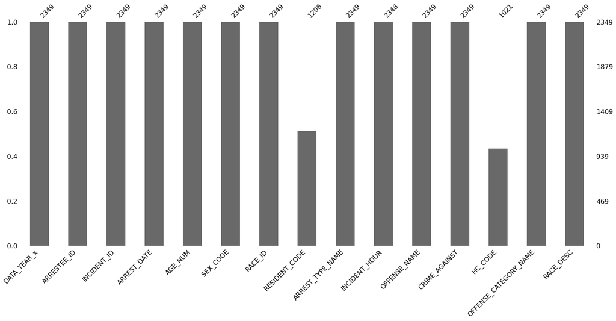

```python
msno.bar(data)
```

```python
data.info()
```

```
<class 'pandas.core.frame.DataFrame'>
RangeIndex: 2349 entries, 0 to 2348
Data columns (total 15 columns):
 #   Column                 Non-Null Count  Dtype
---  ------                 --------------  -----
 0   DATA_YEAR_x            2349 non-null   object
 1   ARRESTEE_ID            2349 non-null   object
 2   INCIDENT_ID            2349 non-null   object
 3   ARREST_DATE            2349 non-null   object
 4   AGE_NUM                2349 non-null   object
 5   SEX_CODE               2349 non-null   object
 6   RACE_ID                2349 non-null   object
 7   RESIDENT_CODE          1206 non-null   object
 8   ARREST_TYPE_NAME       2349 non-null   object
 9   INCIDENT_HOUR          2348 non-null   object
 10  OFFENSE_NAME           2349 non-null   object
 11  CRIME_AGAINST          2349 non-null   object
 12  HC_CODE                1021 non-null   object
 13  OFFENSE_CATEGORY_NAME  2349 non-null   object
 14  RACE_DESC              2349 non-null   object
dtypes: object(15)
memory usage: 275.4+ KB
```

```python
data.describe().T
```

|  | count | unique | top | freq |
| --- | --- | --- | --- | --- |
| DATA_YEAR_x | 2349 | 3 | 2020 | 2241 |
| ARRESTEE_ID | 2349 | 2326 |  | 24 |
| INCIDENT_ID | 2349 | 2283 |  | 24 |
| ARREST_DATE | 2349 | 368 |  | 24 |
| AGE_NUM | 2349 | 65 | 30 | 94 |
| SEX_CODE | 2349 | 28 | M | 1646 |
| RACE_ID | 2349 | 10 | 1 | 1482 |
| RESIDENT_CODE | 1206 | 4 | R | 1079 |
| ARREST_TYPE_NAME | 2349 | 22 | Taken INTO Custody | 1245 |
| INCIDENT_HOUR | 2348 | 39 | 16 | 196 |
| OFFENSE_NAME | 2349 | 52 | Shoplifting | 493 |
| CRIME_AGAINST | 2349 | 21 | Property | 1234 |
| HC_CODE | 1021 | 11 | 9,,0 | 368 |
| OFFENSE_CATEGORY_NAME | 2349 | 57 | Larceny/Theft Offenses | 761 |
| RACE_DESC | 2349 | 9 | White | 1486 |

```python
data.describe(exclude=np.number).T
```

|  | count | unique | top | freq |
| --- | --- | --- | --- | --- |
| DATA_YEAR_x | 2349 | 3 | 2020 | 2241 |
| ARRESTEE_ID | 2349 | 2326 |  | 24 |
| INCIDENT_ID | 2349 | 2283 |  | 24 |
| ARREST_DATE | 2349 | 368 |  | 24 |
| AGE_NUM | 2349 | 65 | 30 | 94 |
| SEX_CODE | 2349 | 28 | M | 1646 |
| RACE_ID | 2349 | 10 | 1 | 1482 |
| RESIDENT_CODE | 1206 | 4 | R | 1079 |
| ARREST_TYPE_NAME | 2349 | 22 | Taken INTO Custody | 1245 |
| INCIDENT_HOUR | 2348 | 39 | 16 | 196 |
| OFFENSE_NAME | 2349 | 52 | Shoplifting | 493 |
| CRIME_AGAINST | 2349 | 21 | Property | 1234 |
| HC_CODE | 1021 | 11 | 9,,0 | 368 |
| OFFENSE_CATEGORY_NAME | 2349 | 57 | Larceny/Theft Offenses | 761 |
| RACE_DESC | 2349 | 9 | White | 1486 |

Cleaning data

check if there is row with only nan values in all dimension

```python
len(data)
```

```
2349
```

```python
data.info()
```

```
<class 'pandas.core.frame.DataFrame'>
RangeIndex: 2349 entries, 0 to 2348
Data columns (total 15 columns):
 #   Column                 Non-Null Count  Dtype
---  ------                 --------------  -----
 0   DATA_YEAR_x            2349 non-null   object
 1   ARRESTEE_ID            2349 non-null   object
 2   INCIDENT_ID            2349 non-null   object
 3   ARREST_DATE            2349 non-null   object
 4   AGE_NUM                2349 non-null   object
 5   SEX_CODE               2349 non-null   object
 6   RACE_ID                2349 non-null   object
 7   RESIDENT_CODE          1206 non-null   object
 8   ARREST_TYPE_NAME       2349 non-null   object
 9   INCIDENT_HOUR          2348 non-null   object
 10  OFFENSE_NAME           2349 non-null   object
 11  CRIME_AGAINST          2349 non-null   object
 12  HC_CODE                1021 non-null   object
 13  OFFENSE_CATEGORY_NAME  2349 non-null   object
 14  RACE_DESC              2349 non-null   object
dtypes: object(15)
memory usage: 275.4+ KB
```

```python
data.dropna(axis = 0, how = 'all', inplace=True)
```

```python
len(data)
```

```
2349
```

DataYear

```python
data['DATA_YEAR_x'].value_counts()
```

```
2020    2241
2021      84
          24
Name: DATA_YEAR_x, dtype: int64
```

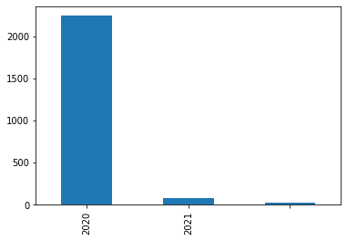

```python
data['DATA_YEAR_x'].value_counts().plot(kind='bar')
```

ArresteeID

```python
# shows a long list of info
pd.set_option('display.max_rows', None)
data['ARRESTEE_ID'].value_counts()
```

[output not shown]

pandas.DataFrame.astype

```python
data['ARRESTEE_ID'] = data['ARRESTEE_ID'].astype(str)
```

```python
# gives a long list again
data['ARRESTEE_ID'].value_counts()
```

[output not shown]

# Task 2

Check values in all dimensions and write down what needs to be done for each dimension:

```
use .value_counts() for checking the values in each dimension
use .plot() to visualise the values in a dimension
Write down the found problems in each dimension
```

```python
# dimensions
data.info()
```

```
<class 'pandas.core.frame.DataFrame'>
Int64Index: 2349 entries, 0 to 2348
Data columns (total 15 columns):
 #   Column                 Non-Null Count  Dtype
---  ------                 --------------  -----
 0   DATA_YEAR_x            2349 non-null   object
 1   ARRESTEE_ID            2349 non-null   object
 2   INCIDENT_ID            2349 non-null   object
 3   ARREST_DATE            2349 non-null   object
 4   AGE_NUM                2349 non-null   object
 5   SEX_CODE               2349 non-null   object
 6   RACE_ID                2349 non-null   object
 7   RESIDENT_CODE          1206 non-null   object
 8   ARREST_TYPE_NAME       2349 non-null   object
 9   INCIDENT_HOUR          2348 non-null   object
 10  OFFENSE_NAME           2349 non-null   object
 11  CRIME_AGAINST          2349 non-null   object
 12  HC_CODE                1021 non-null   object
 13  OFFENSE_CATEGORY_NAME  2349 non-null   object
 14  RACE_DESC              2349 non-null   object
dtypes: object(15)
memory usage: 293.6+ KB
```

```python
data['DATA_YEAR_x'].value_counts()

# 24 do not belong to either year?
```

```
2020    2241
2021      84
          24
Name: DATA_YEAR_x, dtype: int64
```

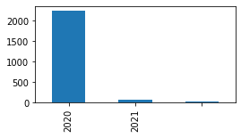

```python
data['DATA_YEAR_x'].value_counts().plot(kind='bar', figsize=(4,2))
```

```python
data['ARRESTEE_ID'].value_counts()

# all data seems ok, though middle is not showing
```

```
            24
41252497     1
38983841     1
38938294     1
41259404     1
            ..
41262947     1
38983928     1
41262361     1
41270887     1
39176496     1
Name: ARRESTEE_ID, Length: 2326, dtype: int64
```

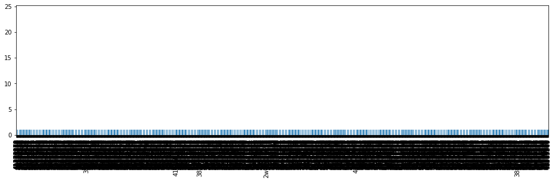

```python
data['ARRESTEE_ID'].value_counts().plot(kind='bar', figsize=(16,4))
```

```python
data['INCIDENT_ID'].value_counts()

# similarly as previous seems alright, but not showing all, unless there is missing value before the ..
```

```
             24
126743999     2
133589443     2
126370276     2
126414375     2
             ..
126746343     1
133664194     1
126370751     1
133580876     1
133576433     1
Name: INCIDENT_ID, Length: 2283, dtype: int64
```

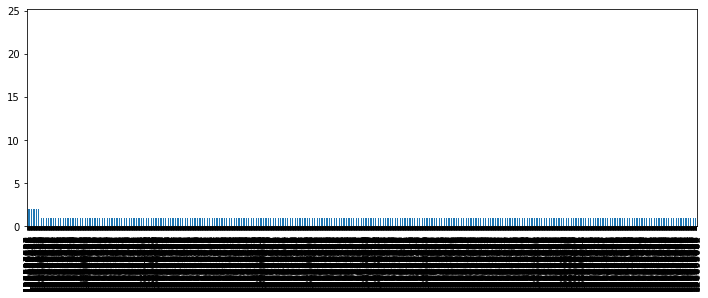

```python
data['INCIDENT_ID'].value_counts().plot(kind='bar', figsize=(12,4))
```

```python
data['ARREST_DATE'].value_counts()

# strange values 14.74.2020, 22.45.2020
```

```
              24
30.Aug.20     18
30.Jul.20     16
17.Jul.20     16
28.Aug.20     16
1.Oct.20      15
16.Nov.20     14
9.Nov.20      14
20.Oct.20     14
20.Aug.20     14
4.Aug.20      13
10.Sep.20     13
3.Dec.20      13
28.Oct.20     13
13.Aug.20     13
27.Oct.20     13
3.Jul.20      13
31.Oct.20     13
27.Nov.20     13
21.Oct.20     13
25.Feb.20     13
30.Sep.20     12
25.Sep.20     12
31.Aug.20     12
18.Dec.20     12
8.Oct.20      12
11.Nov.20     12
4.Dec.20      12
22.Oct.20     12
7.Oct.20      12
18.Aug.20     12
6.Aug.20      11
29.Oct.20     11
10.Nov.20     11
4.Nov.20      11
10.Jul.20     11
12.Oct.20     11
19.Nov.20     11
18.Feb.20     11
22.Aug.20     11
```

[output cut: 314 more lines]

```
20.Sep.20      1
26.Jun.20      1
8.Mar.20       1
13.Jun.20      1
8.Jul.20       1
3.Jan.20       1
3.Jun.20       1
28.Jan.20      1
20.Jan.20      1
27.Mar.20      1
28.Jul.20      1
6.Apr.20       1
30.May.20      1
22.45.2020     1
Name: ARREST_DATE, dtype: int64
```

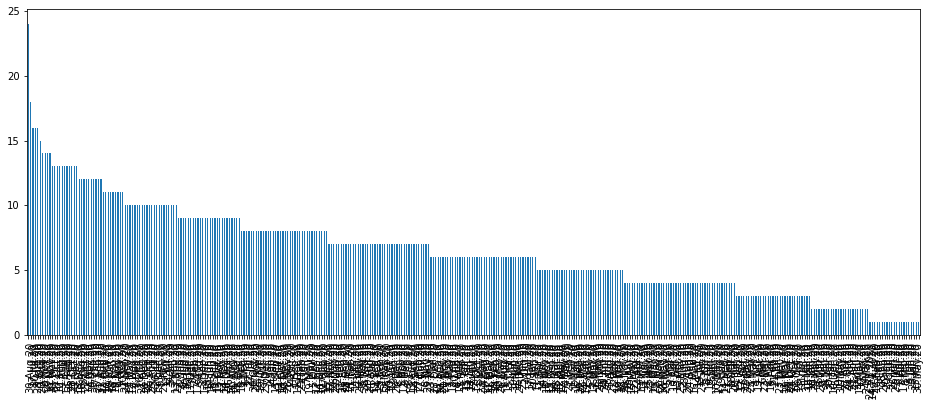

```python
data['ARREST_DATE'].value_counts().plot(kind='bar', figsize=(16,6))
```

```python
data['AGE_NUM'].value_counts()

# one empty __ and 24
```

```
30    94
31    89
29    84
25    83
21    79
37    79
23    76
33    75
22    74
35    72
34    71
27    70
24    69
19    66
32    65
```

[output cut: 51 more lines]

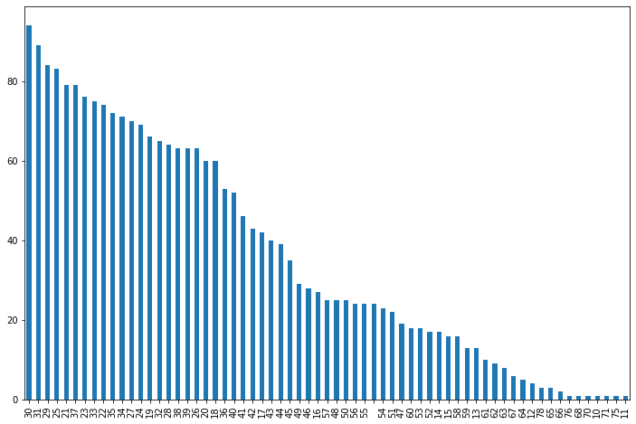

```python
data['AGE_NUM'].value_counts().plot(kind='bar', figsize=(12,8))
```

```python
data['SEX_CODE'].value_counts()

# there are multiple typos for anything other than M and F
```

```
M               1646
F                637
                  24
Female            12
FFeeemalle         3
Femalle            2
M                  2
Mallle             2
Malle              2
F                  1
FFFeeemal le       1
Maleee             1
F em la            1
M a   le           1
Ffemalle           1
f                  1
Male               1
Ma.                1
Maaaaale           1
Feellame           1
M a   le           1
M a l e            1
M  a le            1
Feeemale           1
Femaale            1
F eemela           1
F. emale           1
Maaale             1
Name: SEX_CODE, dtype: int64
```

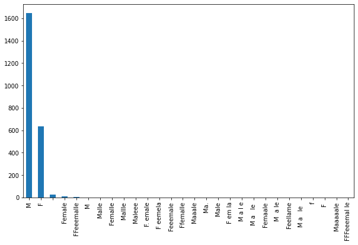

```python
data['SEX_CODE'].value_counts().plot(kind='bar', figsize=(10,6))
```